# Python_project_3_graded_project_Bharath_J

```python
#Import required libraries and read the provided dataset (youtube_dislike_dataset.csv) and retrieve top 5 and bottom 5 records

import pandas as pd
import numpy as np
import matplotlib.pyplot as plt
```

```python
data = pd.read_csv("F:/youtube_dislike_dataset.csv")
data
```

|  | video_id | title | channel_id | channel_title | published_at | view_count | likes | dislikes | comment_count | tags | description | comments |
| --- | --- | --- | --- | --- | --- | --- | --- | --- | --- | --- | --- | --- |
| 0 | --0bCF-iK2E | Jadon Sancho Magical Skills & Goals | UC6UL29enLNe4mqwTfAyeNuw | Bundesliga | 2021-07-01 10:00:00 | 1048888 | 19515 | 226 | 1319 | football soccer ftbol alemn Bundesliga season ... | Enjoy the best skills and goals from Jadon San... | Respect to Dortmund fans,must be sad losing hi... |
| 1 | --14w5SOEUs | Migos - Avalanche (Official Video) | UCGIelM2Dj3zza3xyV3pL3WQ | MigosVEVO | 2021-06-10 16:00:00 | 15352638 | 359277 | 7479 | 18729 | Migos Avalanche Quality Control Music/Motown R... | Watch the the official video for Migos - "Aval... | Migos just makes me want to live my live to th... |
| 2 | --40TEbZ9Is | Supporting Actress in a Comedy: 73rd Emmys | UClBKH8yZRcM4AsRjDVEdjMg | Television Academy | 2021-09-20 01:03:32 | 925281 | 11212 | 401 | 831 |  | Hannah Waddingham wins the Emmy for Supporting... | Hannah's energy bursts through any screen. Wel... |
| 3 | --4tfbSyYDE | JO1'YOUNG (JO1 ver.)' PERFORMANCE VIDEO | UCsmXiDP8S40uBeJYxvyulmA | JO1 | 2021-03-03 10:00:17 | 2641597 | 39131 | 441 | 3745 | PRODUCE101JAPAN JO1 TheSTAR STA... | JO1'YOUNG (JO1 ver.)' PERFORMANCE VIDEO\n\n---... | youngVer>< REN is really PERFECT. It's not ju... |
| 4 | --DKkzWVh-E | Why Retaining Walls Collapse | UCMOqf8ab-42UUQIdVoKwjlQ | Practical Engineering | 2021-12-07 13:00:00 | 715724 | 32887 | 367 | 1067 | retaining wall New Jersey highway Direct Conne... | One of the most important (and innocuous) part... | Keep up with all my projects here: https://pr... |
| ... | ... | ... | ... | ... | ... | ... | ... | ... | ... | ... | ... | ... |
| 37417 | zzd4ydafGR0 | Lil Tjay - Calling My Phone (feat. 6LACK) [Off... | UCEB4a5o_6KfjxHwNMnmj54Q | Lil Tjay | 2021-02-12 05:03:49 | 120408275 | 2180780 | 35871 | 81360 | Lil Tjay Steady Calling My Phone Calling My Ph... | Official video for "Calling My Phone" by Lil T... | 'DESTINED 2 WIN' OUT NOW !! https://liltjay.ln... |
| 37418 | zziBybeSAtw | PELICANS at LAKERS \| FULL GAME HIGHLIGHTS \| Ja... | UCWJ2lWNubArHWmf3FIHbfcQ | NBA | 2021-01-16 05:39:05 | 2841917 | 20759 | 1049 | 2624 | NBA G League Basketball game-0022000187 Lakers... | PELICANS at LAKERS \| FULL GAME HIGHLIGHTS \| Ja... | Montrezl Harrell is going crazy with the rebou... |
| 37419 | zzk09ESX7e0 | [MV] (MAMAMOO) - Where Are We Now | UCuhAUMLzJxlP1W7mEk0_6lA | MAMAMOO | 2021-06-02 09:00:10 | 13346678 | 720854 | 4426 | 90616 | MAMAMOO WAW WAW MAMAMOO WAW Where Are We Now... | [MV] (MAMAMOO) - Where Are We Now\n\nInstagra... | I honestly do not know why this song hit so ha... |
| 37420 | zzmQEb0Em5I | FELLIPE ESCUDERO- Master Podcast #12 | UC8NjnNWMsRqq11NYvHAQb1g | Master Podcast | 2020-10-20 20:59:30 | 252057 | 19198 | 1234 | 1471 | master masterpodcast lord lord vinheteiro z z ... | DOCTOR HAIR\nhttps://www.thedoctorhair.com/?fb... | Foi um prazer passar esta tarde com vocs debat... |
| 37421 | zzxPZwaA-8w | Gareth Bale brace secures dramatic comeback on... | UCEg25rdRZXg32iwai6N6l0w | Tottenham Hotspur | 2021-05-23 21:00:31 | 2252090 | 34063 | 868 | 2004 | Spurs Tottenham Hotspur Tottenham Leicester ... | Two minute highlights from Tottenham Hotspur's... | Thank you Kane for everything you have given t... |

37422 rows × 12 columns

```python
print("printing Top 5 records")
data.head()
```

```
printing Top 5 records
```

|  | video_id | title | channel_id | channel_title | published_at | view_count | likes | dislikes | comment_count | tags | description | comments |
| --- | --- | --- | --- | --- | --- | --- | --- | --- | --- | --- | --- | --- |
| 0 | --0bCF-iK2E | Jadon Sancho Magical Skills & Goals | UC6UL29enLNe4mqwTfAyeNuw | Bundesliga | 2021-07-01 10:00:00 | 1048888 | 19515 | 226 | 1319 | football soccer ftbol alemn Bundesliga season ... | Enjoy the best skills and goals from Jadon San... | Respect to Dortmund fans,must be sad losing hi... |
| 1 | --14w5SOEUs | Migos - Avalanche (Official Video) | UCGIelM2Dj3zza3xyV3pL3WQ | MigosVEVO | 2021-06-10 16:00:00 | 15352638 | 359277 | 7479 | 18729 | Migos Avalanche Quality Control Music/Motown R... | Watch the the official video for Migos - "Aval... | Migos just makes me want to live my live to th... |
| 2 | --40TEbZ9Is | Supporting Actress in a Comedy: 73rd Emmys | UClBKH8yZRcM4AsRjDVEdjMg | Television Academy | 2021-09-20 01:03:32 | 925281 | 11212 | 401 | 831 |  | Hannah Waddingham wins the Emmy for Supporting... | Hannah's energy bursts through any screen. Wel... |
| 3 | --4tfbSyYDE | JO1'YOUNG (JO1 ver.)' PERFORMANCE VIDEO | UCsmXiDP8S40uBeJYxvyulmA | JO1 | 2021-03-03 10:00:17 | 2641597 | 39131 | 441 | 3745 | PRODUCE101JAPAN JO1 TheSTAR STA... | JO1'YOUNG (JO1 ver.)' PERFORMANCE VIDEO\n\n---... | youngVer>< REN is really PERFECT. It's not ju... |
| 4 | --DKkzWVh-E | Why Retaining Walls Collapse | UCMOqf8ab-42UUQIdVoKwjlQ | Practical Engineering | 2021-12-07 13:00:00 | 715724 | 32887 | 367 | 1067 | retaining wall New Jersey highway Direct Conne... | One of the most important (and innocuous) part... | Keep up with all my projects here: https://pr... |

```python
print("printing Bottom 5 records")
data.tail()
```

```
printing Bottom 5 records
```

|  | video_id | title | channel_id | channel_title | published_at | view_count | likes | dislikes | comment_count | tags | description | comments |
| --- | --- | --- | --- | --- | --- | --- | --- | --- | --- | --- | --- | --- |
| 37417 | zzd4ydafGR0 | Lil Tjay - Calling My Phone (feat. 6LACK) [Off... | UCEB4a5o_6KfjxHwNMnmj54Q | Lil Tjay | 2021-02-12 05:03:49 | 120408275 | 2180780 | 35871 | 81360 | Lil Tjay Steady Calling My Phone Calling My Ph... | Official video for "Calling My Phone" by Lil T... | 'DESTINED 2 WIN' OUT NOW !! https://liltjay.ln... |
| 37418 | zziBybeSAtw | PELICANS at LAKERS \| FULL GAME HIGHLIGHTS \| Ja... | UCWJ2lWNubArHWmf3FIHbfcQ | NBA | 2021-01-16 05:39:05 | 2841917 | 20759 | 1049 | 2624 | NBA G League Basketball game-0022000187 Lakers... | PELICANS at LAKERS \| FULL GAME HIGHLIGHTS \| Ja... | Montrezl Harrell is going crazy with the rebou... |
| 37419 | zzk09ESX7e0 | [MV] (MAMAMOO) - Where Are We Now | UCuhAUMLzJxlP1W7mEk0_6lA | MAMAMOO | 2021-06-02 09:00:10 | 13346678 | 720854 | 4426 | 90616 | MAMAMOO WAW WAW MAMAMOO WAW Where Are We Now... | [MV] (MAMAMOO) - Where Are We Now\n\nInstagra... | I honestly do not know why this song hit so ha... |
| 37420 | zzmQEb0Em5I | FELLIPE ESCUDERO- Master Podcast #12 | UC8NjnNWMsRqq11NYvHAQb1g | Master Podcast | 2020-10-20 20:59:30 | 252057 | 19198 | 1234 | 1471 | master masterpodcast lord lord vinheteiro z z ... | DOCTOR HAIR\nhttps://www.thedoctorhair.com/?fb... | Foi um prazer passar esta tarde com vocs debat... |
| 37421 | zzxPZwaA-8w | Gareth Bale brace secures dramatic comeback on... | UCEg25rdRZXg32iwai6N6l0w | Tottenham Hotspur | 2021-05-23 21:00:31 | 2252090 | 34063 | 868 | 2004 | Spurs Tottenham Hotspur Tottenham Leicester ... | Two minute highlights from Tottenham Hotspur's... | Thank you Kane for everything you have given t... |

# 2.Check the info of the dataframe and write your inferences on data types and shape of the dataset.

```python
data.info()
```

```
<class 'pandas.core.frame.DataFrame'>
RangeIndex: 37422 entries, 0 to 37421
Data columns (total 12 columns):
 #   Column         Non-Null Count  Dtype
---  ------         --------------  -----
 0   video_id       37422 non-null  object
 1   title          37422 non-null  object
 2   channel_id     37422 non-null  object
 3   channel_title  37422 non-null  object
 4   published_at   37422 non-null  object
 5   view_count     37422 non-null  int64
 6   likes          37422 non-null  int64
 7   dislikes       37422 non-null  int64
 8   comment_count  37422 non-null  int64
 9   tags           37422 non-null  object
 10  description    37422 non-null  object
 11  comments       37264 non-null  object
dtypes: int64(4), object(8)
memory usage: 3.4+ MB
```

# 3. Check for the Percentage of the missing values and drop or impute them.

```python
data.isnull().sum()
```

```
video_id           0
title              0
channel_id         0
channel_title      0
published_at       0
view_count         0
likes              0
dislikes           0
comment_count      0
tags               0
description        0
comments         158
dtype: int64
```

```python
round(100*(data.isnull().sum()/len(data.index)),2)
```

```
video_id         0.00
title            0.00
channel_id       0.00
channel_title    0.00
published_at     0.00
view_count       0.00
likes            0.00
dislikes         0.00
comment_count    0.00
tags             0.00
description      0.00
comments         0.42
dtype: float64
```

```python
data['comments'].fillna('no comments',inplace=True)
data.isnull().sum()
```

```
video_id         0
title            0
channel_id       0
channel_title    0
published_at     0
view_count       0
likes            0
dislikes         0
comment_count    0
tags             0
description      0
comments         0
dtype: int64
```

# 4. Check the statistical summary of both numerical and categorical columns and write your inferences

```python
print(data.describe())
data.describe(include='object')
```

```
         view_count         likes      dislikes  comment_count
count  3.742200e+04  3.742200e+04  3.742200e+04   3.742200e+04
mean   5.697838e+06  1.668147e+05  4.989862e+03   9.924930e+03
std    2.426622e+07  5.375670e+05  3.070824e+04   1.171003e+05
min    2.036800e+04  0.000000e+00  0.000000e+00   0.000000e+00
25%    5.122970e+05  1.323350e+04  2.810000e+02   9.000000e+02
50%    1.319078e+06  4.233050e+04  7.960000e+02   2.328000e+03
75%    3.670231e+06  1.304698e+05  2.461750e+03   6.184000e+03
max    1.322797e+09  3.183768e+07  2.397733e+06   1.607103e+07
```

|  | video_id | title | channel_id | channel_title | published_at | tags | description | comments |
| --- | --- | --- | --- | --- | --- | --- | --- | --- |
| count | 37422 | 37422 | 37422 | 37422 | 37422 | 37422 | 37422 | 37422 |
| unique | 37422 | 37113 | 10961 | 10883 | 36772 | 28799 | 35630 | 37265 |
| top | --0bCF-iK2E | www | UCNAf1k0yIjyGu3k9BwAg3lg | Sky Sports Football | 2020-10-16 04:00:10 |  |  | no comments |
| freq | 1 | 21 | 533 | 533 | 6 | 3817 | 589 | 158 |

view_count has mean value of 5.697838e+06 and standard deviation of 2.426622e+07 likes has mean value of 1.668147e+05 and standard deviation of 5.375670e+05 dislikes has mean value of 4.989862e+03 and standard deviation of 3.070824e+04 comment_count has mean value of 9.924930e+03 and standard deviation of 1.171003e+05 count of video_id :37422 top value in the name channel_title is Sky Sports Football,

# 5. Convert datatype of column published_at from object to pandas datetime.

```python
pd.to_datetime(data['published_at'])
```

```
0       2021-07-01 10:00:00
1       2021-06-10 16:00:00
2       2021-09-20 01:03:32
3       2021-03-03 10:00:17
4       2021-12-07 13:00:00
                ...
37417   2021-02-12 05:03:49
37418   2021-01-16 05:39:05
37419   2021-06-02 09:00:10
37420   2020-10-20 20:59:30
37421   2021-05-23 21:00:31
Name: published_at, Length: 37422, dtype: datetime64[ns]
```

# 6. Create a new column as 'published_month' using the column published_at (display the months only)

```python
data['published_month']=data['published_at'].dt.month
data['published_month']
```

[output not shown]

# 7. Replace the numbers in the column published_month as names of the months i,e., 1 as 'Jan', 2 as 'Feb'and so on.....

```python
data['published_month']=data['published_at'].dt.month
month_names={1:'jan',2:'feb',3:'march',4:'aprl',5:'may',6:'june',7:'jul',8:'aug',9:'sep',10:'oct',11:'nov',12:'dec'}
data['published_month']=data['published_month'].map(month_names)
data['published_month']
```

```
0          jul
1         june
2          sep
3        march
4          dec
         ...
37417      feb
37418      jan
37419     june
37420      oct
37421      may
Name: published_month, Length: 37422, dtype: object
```

# 8. Find the number of videos published each month and arrange the months in a decreasing order based on the video count.

```python
video_count=data.groupby('published_month').size()
video_count=video_count.sort_values(ascending=False)
video_count
```

```
published_month
oct      4991
sep      4880
nov      4851
aug      4262
dec      3072
jul      2340
june     2316
march    2258
feb      2137
aprl     2126
jan      2108
may      2081
dtype: int64
```

# 9. Find the count of unique video_id, channel_id and channel_title.

```python
video_id_count= data['video_id'].nunique()
print("unique_video_id:",unique_video_id)

unique_channel_id_count= data['channel_id'].nunique()
print("unique_channel_id:",unique_channel_id)

channel_title_count= data['channel_title'].nunique()
print("channel_title_count:",channel_title_count)
```

[output not shown]

# 10. Find the top10 channel names having the highest number of videos in the dataset and the bottom10# having lowest number of videos

```python
top_ten=data['channel_title'].value_counts()
print(' the top 10 heighest number of videos having channel \n',top_ten.head(10))

bottom_ten=data['channel_title'].value_counts()
print(' the bottom 10 lowest number of videos having channel \n',bottom_ten.tail(10))
```

```
 the top 10 heighest number of videos having channel
 Sky Sports Football    533
The United Stand       301
BT Sport               246
NBA                    209
NFL                    162
WWE                    122
SSSniperWolf            99
SSundee                 98
FORMULA 1               87
NHL                     86
Name: channel_title, dtype: int64
 the bottom 10 lowest number of videos having channel
 Eiaz                     1
adidas                   1
Universitetet i Agder    1
Team Tapia               1
TheVincentMottola        1
Blocktrainer             1
Movie Addicts            1
1 1 minute mom           1
FLORIN CERCEL            1
Master Podcast           1
Name: channel_title, dtype: int64
```

# 11. Find the title of the video which has the maximum number of likes and the title of the video having minimum likes and write your inferences.

```python
maximum_likes= data["likes"].idxmax()
maximum_likes_title= data.loc[maximum_likes,"title"]

minimum_likes= data["likes"].idxmin()
minimum_likes_title= data.loc[minimum_likes,"title"]


print("video of the maximum number of likes title:",maximum_likes_title)
print(f"video of the minimum number of likes title:",minimum_likes_title)
```

```
video of the maximum number of likes title: BTS () 'Dynamite' Official MV
video of the minimum number of likes title: Kim Kardashian's Must-See Moments on "Saturday Night Live" | E! News
```

*the maximum number of likes has the popular BTS channel because its entertaining channel so many people like to watch.*the minimum number of likes has the news channel may be people doesn't like to watch news,it could be boring to watch.

# 12. Find the title of the video which has the maximum number of dislikes and the title of the video having minimum dislikes and write your inferences.

```python
maximum_dislikes= data["dislikes"].idxmax()
maximum_dislikes_title= data.loc[maximum_dislikes,"title"]

minimum_dislikes= data["dislikes"].idxmin()
minimum_dislikes_title= data.loc[minimum_dislikes,"title"]


print("video of the maximum number of dislikes title:",maximum_dislikes_title)
print(f"video of the minimum number of dislikes title:",minimum_dislikes_title)
```

[output not shown]

*the video of the maximum number of dislikes title: Cuties | Official Trailer | Netflix people may find not so interesting to watch the trailer so this could be the reason for more dislikes.*video of the minimum number of dislikes title: Kim Kardashian'sim is the one of the top celebrity in the world she is model and business women and her ex-husband is bilionaire who is famously known across the world so that could be the reason for minimum dislikes.

# 13. Does the number of views have any effect on how many people disliked the video? Support your answer with a metric and a plot.

```
correlation between views and dislikes: 0.6844687753905536
```

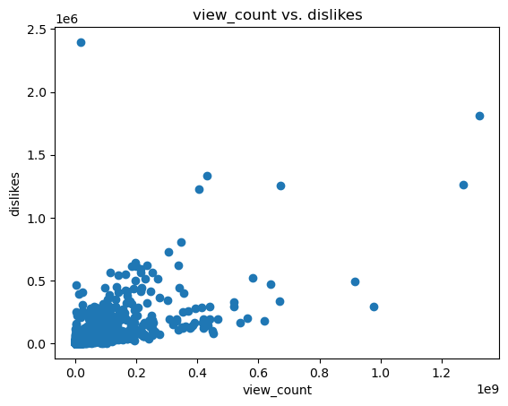

```python
corr=data['view_count'].corr(data['dislikes'])
print("correlation between views and dislikes:",corr)

plt.scatter(data['view_count'],data['dislikes'])
plt.title("view_count vs. dislikes")
plt.xlabel('view_count')
plt.ylabel('dislikes')
plt.show()
```

Based on the correlation coefficient, the relationship between views and dislikes is moderately positive, which suggests that as the number of views increases, the number of dislikes tends to increase as well.

there are likely other factors at play that affect the number of dislikes, so it's important to take this correlation with a grain of salt and consider other variables as well.